# Linear Regression with tidymodels

Predicting average assessment score in the OULAD data

Author

Published

July 15, 2026

# Chapter 4: Linear Regression

## What I’m doing here

These are my notes for building a OLS linear regression model on the OULAD dataset. The goal is to predict `avg_score` — a student’s average assessment score across a module — from things we could plausibly know about them: demographics, how many credits they’re taking, and how much they engage with the online course materials.

This follows Chapter 4 of Boehmke & Greenwell, but using tidymodels instead of caret. The concepts are the same; the syntax is different.

As a reminder, this is a **predictive** model, not a causal one. If `total_clicks` turns out to matter, that doesn’t mean telling students to click more would raise their scores. It means clicking could be correlated with something — motivation, time available, engagement — that does affect scores.

## Setup

```r
library(tidyverse)
library(tidymodels)
library(skimr)
library(caret) # to examine nzv
library(corrr) # correlation check
library(rcompanion) # correlation check
library(DALEXtra) # explain models

set.seed(1234)
```

Without seed, the train/test split would be different every time I run this code and my numbers wouldn’t match what I wrote in my narrative.

## Data dictionary

Keeping this here for reference.

```
IDENTIFIERS
  id_student          Unique student identifier

COURSE CONTEXT
  code_module         Course module code (AAA-GGG, 7 modules)
  code_presentation   Presentation period (e.g., "2013J" = 2013 Fall)
  domain              STEM or Social Science (determined by code_module)

STUDENT DEMOGRAPHICS
  gender              M or F
  region              UK region of residence
  highest_education   Prior education level
  imd_band            Index of Multiple Deprivation band (0-10% most deprived)
  age_band            0-35, 35-55, or 55<=
  disability          Y/N

ENROLLMENT
  num_of_prev_attempts        Prior attempts at this module
  studied_credits             Credits enrolled this presentation
  date_registration           Days relative to module start (negative = early)
  date_unregistration         Days to withdrawal (NA if completed) - LEAKAGE
  module_presentation_length  Module length in days

ENGAGEMENT
  total_clicks        Total VLE clicks
  total_days_active   Distinct days with activity
  n_assessments       Assessments taken

ASSESSMENT PERFORMANCE
  avg_score           Average score (0-100) - TARGET
  min_score           Lowest score - LEAKAGE
  max_score           Highest score - LEAKAGE
  n_failed            Count of failed assessments - LEAKAGE
  avg_days_early      Average days submitted early (negative = late)

OUTCOME
  final_result        Pass / Distinction / Fail / Withdrawn
  wf                  Binary target for the classification version
```

## Loading and cleaning

A bunch of columns come in as character because of how missing values were written in the source file. Coercing them to numeric so the recipe can work with them.

```r
oulad_raw <- read_csv("oulad_clean.csv")
oulad <- oulad_raw %>%
  mutate(
    avg_score         = as.numeric(avg_score),
    avg_days_early    = as.numeric(avg_days_early),
    n_assessments     = as.numeric(n_assessments),
    total_clicks      = as.numeric(total_clicks),
    total_days_active = as.numeric(total_days_active),
    date_registration = as.numeric(date_registration)
  )

glimpse(oulad)
```

```
Rows: 32,593
Columns: 25
$ code_module                <chr> "AAA", "AAA", "AAA", "AAA", "AAA", "AAA", "…
$ code_presentation          <chr> "2013J", "2013J", "2013J", "2013J", "2013J"…
$ id_student                 <dbl> 11391, 28400, 30268, 31604, 32885, 38053, 4…
$ gender                     <chr> "M", "F", "F", "F", "F", "M", "M", "F", "F"…
$ region                     <chr> "East Anglian Region", "Scotland", "North W…
$ highest_education          <chr> "HE Qualification", "HE Qualification", "A …
$ imd_band                   <chr> "90-100%", "20-30%", "30-40%", "50-60%", "5…
$ age_band                   <chr> "55<=", "35-55", "35-55", "35-55", "0-35", …
$ num_of_prev_attempts       <dbl> 0, 0, 0, 0, 0, 0, 0, 0, 0, 0, 0, 0, 0, 0, 0…
$ studied_credits            <dbl> 240, 60, 60, 60, 60, 60, 60, 120, 90, 60, 6…
$ disability                 <chr> "N", "N", "Y", "N", "N", "N", "N", "N", "N"…
$ final_result               <chr> "Pass", "Pass", "Withdrawn", "Pass", "Pass"…
$ date_registration          <dbl> -159, -53, -92, -52, -176, -110, -67, -29, …
$ date_unregistration        <dbl> NA, NA, 12, NA, NA, NA, NA, NA, NA, NA, NA,…
$ avg_score                  <dbl> 82.0, 66.4, NA, 76.0, 54.4, 68.0, 68.0, 72.…
$ min_score                  <dbl> 78, 60, NA, 71, 30, 50, 62, 72, 68, 71, 68,…
$ max_score                  <dbl> 85, 70, NA, 88, 75, 79, 75, 73, 75, 81, 80,…
$ n_assessments              <dbl> 5, 5, NA, 5, 5, 5, 5, 5, 5, 5, 5, 5, 5, 5, …
$ n_failed                   <dbl> 0, 0, NA, 0, 2, 0, 0, 0, 0, 0, 0, 0, 0, 0, …
$ avg_days_early             <dbl> 1.8, 0.0, NA, 2.0, -11.4, -2.0, -0.4, -2.6,…
$ module_presentation_length <dbl> 268, 268, 268, 268, 268, 268, 268, 268, 268…
$ total_clicks               <dbl> 934, 1435, 281, 2158, 1034, 2445, 1492, 142…
$ total_days_active          <dbl> 40, 80, 12, 123, 70, 143, 90, 105, 122, 142…
$ domain                     <chr> "Social Sciences", "Social Sciences", "Soci…
$ wf                         <chr> "Successful", "Successful", "WF", "Successf…
```

```r
Sys.time()
```

```
[1] "2026-07-15 10:36:38 CDT"
```

This mutate happens **before** the split, and that’s fine. Type coercion doesn’t learn anything from the data — turning `"52.5"` into `52.5` gives the same answer no matter which rows are around it. Compare that to something like imputation, which learns a median from the training rows and would leak if I did it out here.

## Looking at the data before I model anything

```r
skim(oulad)
```

Data summary

| Name | oulad |
| --- | --- |
| Number of rows | 32593 |
| Number of columns | 25 |
| _______________________ |  |
| Column type frequency: |  |
| character | 11 |
| numeric | 14 |
| ________________________ |  |
| Group variables | None |

**Variable type: character**

| skim_variable | n_missing | complete_rate | min | max | empty | n_unique | whitespace |
| --- | --- | --- | --- | --- | --- | --- | --- |
| code_module | 0 | 1.00 | 3 | 3 | 0 | 7 | 0 |
| code_presentation | 0 | 1.00 | 5 | 5 | 0 | 4 | 0 |
| gender | 0 | 1.00 | 1 | 1 | 0 | 2 | 0 |
| region | 0 | 1.00 | 5 | 20 | 0 | 13 | 0 |
| highest_education | 0 | 1.00 | 15 | 27 | 0 | 5 | 0 |
| imd_band | 1111 | 0.97 | 5 | 7 | 0 | 10 | 0 |
| age_band | 0 | 1.00 | 4 | 5 | 0 | 3 | 0 |
| disability | 0 | 1.00 | 1 | 1 | 0 | 2 | 0 |
| final_result | 0 | 1.00 | 4 | 11 | 0 | 4 | 0 |
| domain | 0 | 1.00 | 4 | 15 | 0 | 2 | 0 |
| wf | 0 | 1.00 | 2 | 10 | 0 | 2 | 0 |

**Variable type: numeric**

| skim_variable | n_missing | complete_rate | mean | sd | p0 | p25 | p50 | p75 | p100 | hist |
| --- | --- | --- | --- | --- | --- | --- | --- | --- | --- | --- |
| id_student | 0 | 1.00 | 706687.67 | 549167.31 | 3733 | 508573.00 | 590310.0 | 644453.00 | 2716795 | ▅▇▁▁▁ |
| num_of_prev_attempts | 0 | 1.00 | 0.16 | 0.48 | 0 | 0.00 | 0.0 | 0.00 | 6 | ▇▁▁▁▁ |
| studied_credits | 0 | 1.00 | 79.76 | 41.07 | 30 | 60.00 | 60.0 | 120.00 | 655 | ▇▁▁▁▁ |
| date_registration | 45 | 1.00 | -69.41 | 49.26 | -322 | -100.00 | -57.0 | -29.00 | 167 | ▁▂▇▃▁ |
| date_unregistration | 22521 | 0.31 | 49.76 | 82.46 | -365 | -2.00 | 27.0 | 109.00 | 444 | ▁▁▇▂▁ |
| avg_score | 6773 | 0.79 | 72.77 | 16.37 | 0 | 64.67 | 76.0 | 84.55 | 100 | ▁▁▃▇▇ |
| min_score | 6773 | 0.79 | 55.66 | 22.19 | 0 | 42.00 | 60.0 | 72.00 | 100 | ▂▃▇▇▂ |
| max_score | 6773 | 0.79 | 86.54 | 17.10 | 0 | 80.00 | 92.0 | 100.00 | 100 | ▁▁▁▂▇ |
| n_assessments | 6773 | 0.79 | 6.73 | 3.77 | 1 | 4.00 | 7.0 | 10.00 | 14 | ▇▇▅▇▅ |
| n_failed | 6773 | 0.79 | 0.29 | 0.72 | 0 | 0.00 | 0.0 | 0.00 | 9 | ▇▁▁▁▁ |
| avg_days_early | 6774 | 0.79 | 12.00 | 26.40 | -187 | -1.50 | 0.6 | 11.00 | 236 | ▁▁▇▁▁ |
| module_presentation_length | 0 | 1.00 | 256.01 | 13.18 | 234 | 241.00 | 262.0 | 268.00 | 269 | ▇▁▁▅▇ |
| total_clicks | 3365 | 0.90 | 1355.04 | 1733.55 | 1 | 260.75 | 739.5 | 1770.00 | 24139 | ▇▁▁▁▁ |
| total_days_active | 3365 | 0.90 | 61.86 | 54.03 | 1 | 18.00 | 47.0 | 92.00 | 286 | ▇▃▂▁▁ |

The `complete_rate` column is the interesting one. Several engagement variables have real missingness — students who never touched the VLE don’t have click counts.

### How much of the target is missing?

These are students who never submitted an assessment, so they have no average score. I can’t train on them — the model needs to see the answer to learn.

```r
oulad %>%
  summarise(
    n_rows             = n(),
    n_missing_target   = sum(is.na(avg_score)),
    pct_missing_target = mean(is.na(avg_score)) * 100
  )
```

```
# A tibble: 1 × 3
  n_rows n_missing_target pct_missing_target
   <int>            <int>              <dbl>
1  32593             6773               20.8
```

### Did I load the correct data?

Here is an image of my code to hightlight something I want `Dr. Littrell` to see:

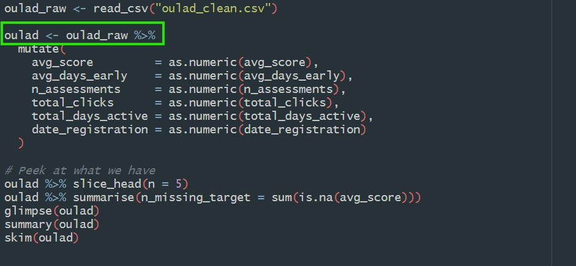

### Here is the breakdown of the code_module distribution:

This visual shows the various modules and their breakdown in the data.

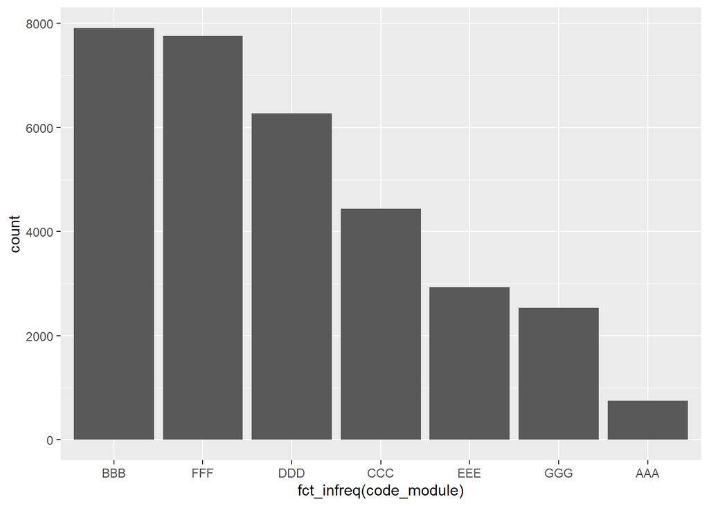

```r
oulad %>%
  ggplot(aes(fct_infreq(code_module))) +
  geom_bar()
```

# Chapter 5: Logistic Regression